# K-means

First we use the classical K-means method to do clustering analysis, with optimal cluster number chosen as 2.

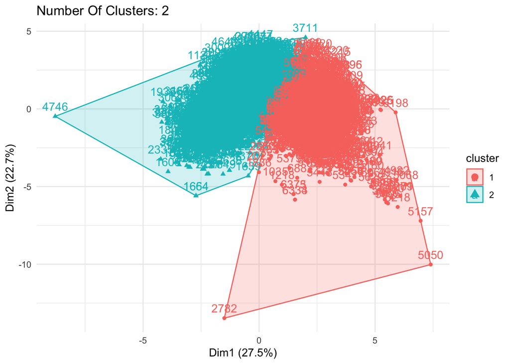

We extract the clusters results and add them back to our initial data to do some descriptive statistics at the cluster level(Here for convenience, we temporarily view `red` as a numeric variable):

| Cluster | fixed.acidity | volatile.acidity | citric.acid | residual.sugar | chlorides | free.sulfur.dioxide | total.sulfur.dioxide | density | pH | sulphates | alcohol | quality | red |
| --- | --- | --- | --- | --- | --- | --- | --- | --- | --- | --- | --- | --- | --- |
| 1 | 8.290 | 0.532 | 0.270 | 2.634 | 0.088 | 15.765 | 48.640 | 0.997 | 3.310 | 0.657 | 10.402 | 5.602 | 0.959 |
| 2 | 6.852 | 0.275 | 0.335 | 6.394 | 0.045 | 35.522 | 138.458 | 0.994 | 3.188 | 0.489 | 10.522 | 5.892 | 0.005 |

It can be shown that from our output, there are two clusters. Red wine mainly dominates cluster 1, whereas white wine mainly dominates cluster 2, which is quite reasonable.

# Partition Around Medoids

In order to validate the clustering result, we use a different clustering method. An alternative to K-means clustering is the K-medoids clustering or PAM (Partitioning Around Medoids, Kaufman & Rousseeuw, 1990), which is less sensitive to outliers compared to K-means.

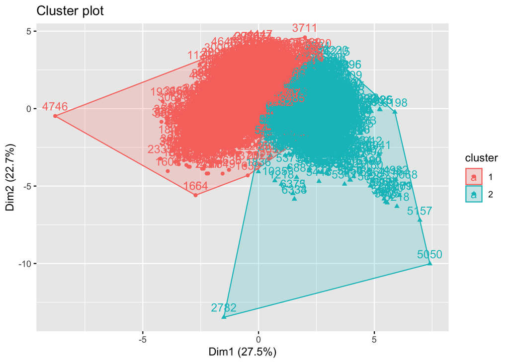

| Cluster | fixed.acidity | volatile.acidity | citric.acid | residual.sugar | chlorides | free.sulfur.dioxide | total.sulfur.dioxide | density | pH | sulphates | alcohol | quality | red |
| --- | --- | --- | --- | --- | --- | --- | --- | --- | --- | --- | --- | --- | --- |
| 1 | 6.849 | 0.276 | 0.334 | 6.349 | 0.045 | 35.395 | 137.727 | 0.994 | 3.190 | 0.492 | 10.541 | 5.894 | 0.015 |
| 2 | 8.355 | 0.539 | 0.269 | 2.626 | 0.089 | 15.372 | 47.334 | 0.997 | 3.306 | 0.653 | 10.338 | 5.584 | 0.965 |

We notice that the result output by K-means and PAM does not differ too much due to the innate characteristic of our dataset(red wine and white wine). For simplicity, we will just use the result of K-means for the following analysis.

# Visualization

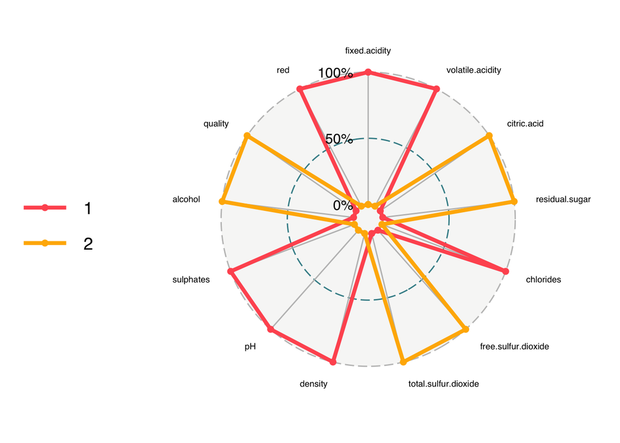

From clustering analysis, we can see obvious characteristics of red wine and white wine visualized by the radar chart:

- Cluster 1(mainly red wine) has higher fixed acidity, volatile acidity, chlorides, sulphates, pH and density.
- Cluster 2(mainly white wine) has higher citric acid, residual sugar, free sulfur dioxide, total sulfur dioxide, alcohol and quality.

# References:

- Han, Jiawei, Micheline Kamber, and Jian Pei. 2012. Data Mining: Concepts and Techniques. 3rd ed. Boston: Morgan Kaufmann.
- Lawson, Richard G., and Peter C. Jurs. 1990. “New Index for Clustering Tendency and Its Application to Chemical Problems.” Journal of Chemical Information and Computer Sciences 30 (1): 36–41.
- Kaufman, Leonard, and Peter J. Rousseeuw. 1990 “Partitioning around medoids (program pam).” Finding groups in data: an introduction to cluster analysis 344 : 68-125.